# Coursework Report

*N* removed NAs: 3

*N* removed <18: 27

*N* total clean: 118

| Group | *N* | *M*<sub>age</sub> | *M*<sub>rating</sub> |
| --- | --- | --- | --- |
| Control | 58 | 21.00 | 6.72 |
| Experim | 60 | 20.33 | 5.64 |

**Main analysis results**

*t*(116) = 7.67, *p* < .001

# Coursework Report

Analysing Data, Spring 2020

# Methods

This paper is a replication of Elliot et al.’s (2010) original study investigating the link between red and perceived attractiveness.

## Participants

Table 1 *Descriptive Statistics For Ages of Participants by Condition*

| Group | *N* | *M*<sub>age</sub> | SD | Min | Max |
| --- | --- | --- | --- | --- | --- |
| White | 58 | 21.00 | 1.92 | 18 | 26 |
| Red | 60 | 20.33 | 1.77 | 18 | 25 |

## Design

Participants saw a black and white photo of a man for 5 seconds on either a red (n = 60) or a white (n = 58) background, thus the experiment was a between-subjects design. Participants then answered questions (see appendix) on a likert scale where 0 = not attractive to 9 = extremely attractive. Individual composite scores were made for each participant by averaging their ratings from the questions to get an overall value. We used an independent-measures *t*-test to analyses whether the difference in ratings were of statistical significance (p<0.05). The background colour manipulation (i.e. the independent variable) is a factor variable as participants were either in the red or white group. The participants individual composite score (i.e. the dependent variable) is a continuous variable as they were measured using a 9-point scale. It was hypothesized that viewing red increases women’s ratings of men’s attractiveness and sexual desirability, so participants who viewed the stimuli on a red background would obtain a higher composite score.

# Results

The analysis results did not support the hypotheses as the control group had a higher mean attractiveness score (*M* = 6.72) than the experimental group (*M* = 5.64), as shown in Figure one. This difference in means was significant (*M*<sub>diff</sub> = 1.07, 95% CI [0.8, 1.35], *t* (116) = 7.67, *p* = .0000000).

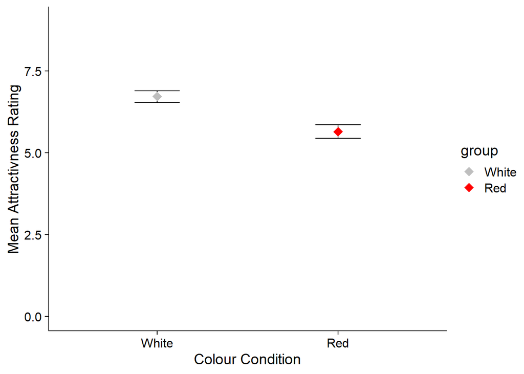

Figure 1 *Point Plot of Mean Attractiveness Scale Score For Both Conditions*

The probability of finding t as large as was found (7.67) was very small (p < 0.01). Therefore, it is likely that the sample means came from different populations i.e. those who saw the red background and those who saw the white background. As a reult, the null hypothesis is rejected, and the alternative hypothesis is accepted. The analyses suggest that background colour influences the ratings of attractiveness, however this relationship is not in the direction found by the original study which saw red increasing rated attractiveness.

Table 2 *Descriptive Statistics of Attractivness Ratings by Condition*

| Group | Mean | SD | Min | Max |
| --- | --- | --- | --- | --- |
| White | 6.72 | 0.69 | 4.67 | 8.00 |
| Red | 5.64 | 0.83 | 3.67 | 7.33 |

It is clear that the experimental group repeatedly gave lower ratings, indicating more participants in this group found the stimuli less attractive (figure two).

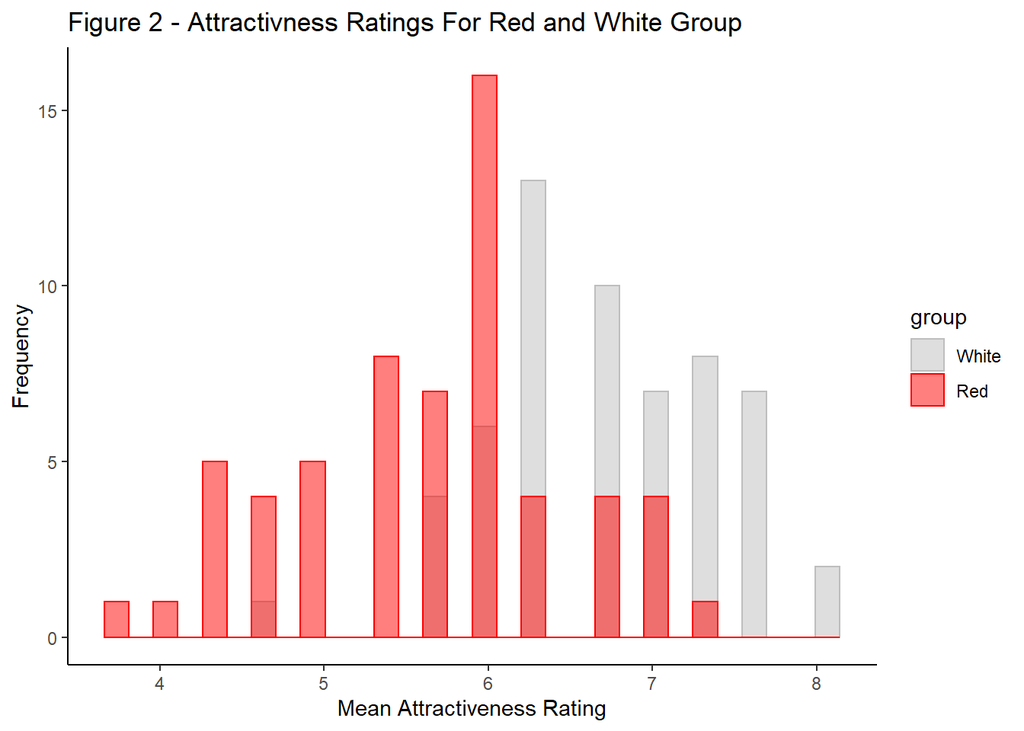

# Discussion

The present results show that females rated males as more attractive when they saw a white background (M = 6.72, *SD* = 0.69) than those who saw a red background (M= 5.64, *SD* = 0.83). These results question the red effect proposed by Elliot et al’s (2010) original study. Our data contrasts the red effect from the original, thus reducing its reliability. This difference could be due to the original study using only 21 participants whereas our replication included 118 females. The larger sample increase the validity of my results and the conclusions can be more readily applied to the target population. My results could be due to the colour white’s symbolizing different meanings to red. White has links to purity and innocence (Peperkoorn, Roberts & Pollet, 2016). whereas red is associated with lust, love, and sexuality (Elliot & Maier, 2012 cited by Peperkoorn et al, 2016). Females have been shown to be choosier when selecting potential mates, tending to prefer males who are intelligent and have the potential for money and status (Hatfield & Sprecher, 1995). This was noted in Elliot et al’s paper where they explain that female’s biological heritage and/or cultural learning causes a relationship between red and their perceived attractiveness of males due to the colours links to status and health. So females prefer mates who are able to provide them with resources, however this ability is predicted by how many mates the males has i.e. how spread their resources will be. Therefore females may prefer men in conjunction with the colour white as this symbolized chastity, meaning there is less competition between the males female mates for the resources that he brings. This idea could explain why the females in the present replication had a preference for the males against a white background.

Francis (2013) argued that Elliot et al.’s study contains publication bias. He explains the null hypothesis rejection of all 12 of their studies is too consistent considering the power and small sample sizes. Francis goes on to say that if the red effect is true, there should be replications which fail to reject the null hypothesis. However, the current replication found a significant result but in the opposite direction to Elliot et al therefore reducing the legitimacy of the red effect. Elliot and Maier (2013) replied to Francis’ criticism where they replicated of one of the original experiments. Red was still found to influence attraction, but the effect was not significant. However as Francis noted, this can be seen to support the red effect. Our results do not fit with the replication in their paper because it still suggests that women find men more attractive when in conjunction with the colour red. However, Elliot and Maier’s paper does shed light on how applicable the Francis paper is as a means of criticism for the original study. Our results are in line with Hesslinger, Goldbach and Carbon’s (2015) study which did not find a significant difference between the ratings from the colour conditions despite also using a larger sample size (N=161). However, their methods were not an exact replication as participants were tested in one group session (not individually) which may have led to extraneous variables affecting the ratings thus reducing the study’s validity. Nevertheless, our results are significant so do not support the red effect unlike this study which Francis could argue shows support for it as there will be instances which fail to reject the null hypothesis. Peperkoorn et al. also failed to find a red effect which concurs with our results, they state that this “questions the robustness of the red effect in human mate preferences” (p.10). However, they used male participants viewing females and focused on changing the colour of the clothing instead of the background so the study was not an exact replication of the original.

The current study used a larger sample which is beneficial as it increases the power of the sample meaning this replication can be relied upon as evidence which refutes the red effect. A larger sample means an increased amount of data, so the findings are more generalizable to the population. Also, the between-subjects design meant no participant experienced both conditions; this adds internal validity as participants were less likely to guess the study’s aim and show demand characteristics. The laboratory setting allowed precise manipulation of the independent variable so any effect on the dependent variable was likely to be due to the intended change, allowing a cause and effect relationship to be established. The experimenters were blind to the participants colour condition, so no participants behaviour was affected by experimenter effects such as body language. On the other hand, the artificial laboratory setting may not be representative of the real world, thus the results may not generalize to more naturalistic settings. Hesslinger et al. incorporated apparel style as a factor affecting attractiveness and found this significantly affected ratings. They also note that the male stimuli does not match the variability of individual looks in real life, leaving open the question of whether the red effect will be found in individuals who are considered to not be of medium level of attractiveness (unlike the male stimuli used). Dion, Berscheid and Walster (1972) found a halo effect where attractive people are perceived in a more positive light, therefore it could be that the males were considered attractive and this caused the participants to attribute positive characteristics to them which influenced their ratings, not the background colour. Further credible replications using larger sample sizes than the original must be conducted in order to evaluate and expand the scope of the red effect. Hatfield and Sprecher (1995) state that all women have evolved to be choosier and prefer mates with traits signalling health and status, they call for more cross-cultural investigations to get a global view of the red effect (or lack of) in different cultures and how it may differ. The replication used a laboratory setting like the original. This artificial setting may affect participants behaviour which limits the generalizability of the results. Future research should use a naturalistic setting so the results can be more readily applied to the target population and other factors can be explored. For example, Hesslinger et al. found a relationship between clothing style and measures of attractiveness. Due to the current paper being a replication, the methodology was restricted to that used by the original. Peperkoorn et al. postulated that the red effect may be different if the viewing time of the stimuli is over 5 seconds. Thus future replications should extend the viewing time to 10 seconds and 15 seconds to see the ref effect persists beyond the 5s limited time frame, additionally this would be more realistic to real world encounters. Also, future research should use stimuli of males which are in colour instead of black and white. This would reflect everyday experiences of viewing potential partners meaning the internal validity and generalisability of the results.

In conclusion, my data provides evidence against the red effect due to the fact that the mean average attractiveness rating for the participants who saw the red background (m = 5.64) was less than that given by the participants who saw the white background (m = 6.72). This contrasts the conclusions from Elliot et al.’s original study. Our findings could be explained by women choosing mates with high status and many resources but this is mediated by how many partners they perceive the male has as this will influence how thinly his resources are spread. While my data does show that there are relationships between colour perception and subsequent psychological functioning, it does not however inform us of additional ecological valid factors which may emerge in the real world, and whether the red effect extends beyond a laboratory setting or to other cultures. My lack of finding a red effect coincides with other studies such as Hesslinger et al and Peperkoorn et al; however, unlike these studies, we found a significant relationship but this was in the opposite direction to that found in the original paper. Future replications must be conducted in order to investigate the possible red effect further and expand the scope of the current literature.

# Appendix

Question 1: “How attractive do you think this person is?”

Question 2:“How pleasant is this person to look at?”

Question 3:“If I were to meet the person in this picture face to face, I would think that he is attractive.”

# References

Dion, K., Berscheid, E., & Walster, E. (1972). What is beautiful is good. Journal of Personality and Social Psychology, 24, 285–290.

Elliot, A., Niesta Kayser, D., Greitemeyer, T., Lichtenfeld, S., Gramzow, R., Maier, M., & Liu, H. (2010). Red, rank, and romance in women viewing men. Journal Of Experimental Psychology: General, 139(3), 399-417. doi: 10.1037/a0019689.

Elliot, A. J., & Maier, M. A. (2012). Color-in-context theory. In A. Devine & P. Plant (Ed.), Advances in experimental social psychol- ogy 45 (pp. 63–125). New York, NY: Academic Press.

Elliot, A., & Maier, M. (2013). The red-attractiveness effect, applying the Ioannidis and Trikalinos (2007b) test, and the broader scientific context: A reply to Francis (2013). Journal Of Experimental Psychology: General, 142(1), 297-300. doi: 10.1037/a0029592.

Francis, G. (2013). Publication bias in “Red, rank, and romance in women viewing men,” by Elliot et al. (2010). Journal Of Experimental Psychology: General, 142(1), 292-296. doi: 10.1037/a0027923.

Hatfield, E., & Sprecher, S. (1995). Men’s and Women’s

Preferences in Marital Partners in the United States, Russia, and Japan. Journal Of Cross-Cultural Psychology, 26(6), 728-750. doi: 10.1177/002202219502600613.

Hesslinger, V., Goldbach, L., & Carbon, C. (2015). Men in red: A reexamination of the red-attractiveness effect. Psychonomic Bulletin & Review, 22(4), 1142-1148. doi: 10.3758/s13423-015-0866-8.

Ioannidis, J. P. A., & Trikalinos, T. A. (2007b). An exploratory test for an excess of significant findings. Clinical Trials, 4, 245–253. doi:10.1177/ 1740774507079441.

Peperkoorn, L., Roberts, S., & Pollet, T. (2016). Revisiting the Red Effect on Attractiveness and Sexual Receptivity. Evolutionary Psychology, 14(4), 147470491667384. doi: 10.1177/1474704916673841.